# Intro to Pandas

# Intro to Pandas DataFrame

```python
import numpy as np
import pandas as pd
import matplotlib.pyplot as plt
%matplotlib inline
from jupyterthemes import jtplot
jtplot.style('grade3')
```

## pandas.DataFrame

저번 콘텐츠에서 배운 pandas.Series의 개념들은 판다스의 또다른 대표적 자료구조인 pandas.DataFrame에서도 그대로 적용이 가능합니다. 데이터 프레임은 특정 인덱스를 갖는 2차원 테이블 이라고 생각하시면 쉽게 이해할 수 있습니다. 인덱스인 날짜와 해당 날짜의 시가(open), 고가(high), 저가(low), 종가(close), 거래량(volume)의 정보를 가지고 있는 일반적인 주가데이터나 엑셀의 스프레드시트를 떠올리시면 됩니다. 저번 콘텐츠에서 아래와 같이 pandas_datareader모듈을 사용하여 가격정보를 불러왔었습니다. prices라는 변수에 저장된 가격정보는 데이터프레임 타입을 가지고 있습니다.

```python
import pandas_datareader as web
symbol = 'AAPL'
start = '2016-01-01'
end = '2019-03-04'
prices = web.DataReader(symbol,'iex', start, end)
prices.head()
```

| date | open | high | low | close | volume |
| --- | --- | --- | --- | --- | --- |
| 2016-01-04 | 96.9111 | 99.5159 | 96.3350 | 99.4989 | 67649387 |
| 2016-01-05 | 99.8767 | 99.9711 | 96.7222 | 97.0055 | 55790992 |
| 2016-01-06 | 94.9749 | 96.6844 | 94.3233 | 95.1072 | 68457388 |
| 2016-01-07 | 93.1993 | 94.5688 | 91.0743 | 91.0932 | 81094428 |
| 2016-01-08 | 93.0766 | 93.6055 | 91.3860 | 91.5749 | 70798016 |

```python
print(type(prices))
```

```
<class 'pandas.core.frame.DataFrame'>
```

DataFrmae은 pandas.DataFrame() 함수를 사용해 생성이 가능하며 함수안에 dictionary 또는 넘파이 ndarray를 입력하면 해당 객체가 dataFrame으로 변경됩니다. 또한 여러개의 Series를 pandas.concat() 메서드를 활용하여 dataFrame으로 합성이 가능합니다. 이 외에 다른 기능들은 [판다스 데이터프레임 공식문서](https://pandas.pydata.org/pandas-docs/stable/reference/api/pandas.DataFrame.html)를 참고하시면 됩니다. 여기서는 dictionary를 데이터 프레임으로 변환해 보겠습니다.

```python
dict_data = {
    'a' : [1, 2, 3, 4, 5],
    'b' : ['L', 'K', 'J', 'M', 'Z'],
    'c' : np.random.normal(0, 1, 5)
}
print(dict_data)
```

```
{'a': [1, 2, 3, 4, 5], 'b': ['L', 'K', 'J', 'M', 'Z'], 'c': array([-0.05548304, -0.87560184,  0.25078361,  0.42431009,  0.6577422 ])}
```

Series를 생성할 때와 같이 손쉽게 날짜 인덱싱이 가능합니다.

```python
frame_data = pd.DataFrame(dict_data, index=pd.date_range('2016-01-01', periods=5))
frame_data
```

|  | a | b | c |
| --- | --- | --- | --- |
| 2016-01-01 | 1 | L | -0.055483 |
| 2016-01-02 | 2 | K | -0.875602 |
| 2016-01-03 | 3 | J | 0.250784 |
| 2016-01-04 | 4 | M | 0.424310 |
| 2016-01-05 | 5 | Z | 0.657742 |

위에서 언급했던 여러개의 Series 구조를 하나의 DataFrame으로 합칠수 있습니다. pandas.concat() 메서드를 활용할 경우 axis라는 키워드를 통해 합칠 방향(0:세로방향, 1:가로방향)을 정할 수 있으며, 자동으로 같은 인덱스끼리 데이터가 정렬되어 하나의 데이터프레임으로 합쳐지게 됩니다. 아래 예제의 경우 두 시리즈 모두 같은 정수형 인덱스를 가지기 때문에 다음과 같이 합쳐지게 됩니다.

```python
s_1 = pd.Series([2, 4, 6, 8, 10], name='Evens')
s_2 = pd.Series([1, 3, 5, 7, 9], name="Odds")
numbers = pd.concat([s_1, s_2], axis=1)
numbers
```

|  | Evens | Odds |
| --- | --- | --- |
| 0 | 2 | 1 |
| 1 | 4 | 3 |
| 2 | 6 | 5 |
| 3 | 8 | 7 |
| 4 | 10 | 9 |

위에서 불러온 prices 데이터 프레임을 바탕으로 몇가지 명령어들을 살펴보도록 하겠습니다. DataFrame.head() 명령어를 통해 상위 5개의 데이터를 살펴볼 수 있습니다. 괄호안에 숫자를 입력하면 해당 개수만큼 데이터를 가져옵니다.

```python
prices.head()
```

| date | open | high | low | close | volume |
| --- | --- | --- | --- | --- | --- |
| 2016-01-04 | 96.9111 | 99.5159 | 96.3350 | 99.4989 | 67649387 |
| 2016-01-05 | 99.8767 | 99.9711 | 96.7222 | 97.0055 | 55790992 |
| 2016-01-06 | 94.9749 | 96.6844 | 94.3233 | 95.1072 | 68457388 |
| 2016-01-07 | 93.1993 | 94.5688 | 91.0743 | 91.0932 | 81094428 |
| 2016-01-08 | 93.0766 | 93.6055 | 91.3860 | 91.5749 | 70798016 |

DataFrame.columns 명령어를 사용해 해당 데이터프레임의 열(column) 목록을 확인 가능하며 다른 리스트 값을 집어넣어 변경또한 가능합니다.

```python
prices.columns
```

```
Index(['open', 'high', 'low', 'close', 'volume'], dtype='object')
```

시리즈와 같이 인덱스(index)에 접근이 가능하며 저번 콘텐츠에서 처럼 날짜형식으로 인덱스를 바꾸어 주도록 하겠습니다.

```python
prices.index = pd.to_datetime(prices.index)
prices.index
```

```
DatetimeIndex(['2016-01-04', '2016-01-05', '2016-01-06', '2016-01-07',
               '2016-01-08', '2016-01-11', '2016-01-12', '2016-01-13',
               '2016-01-14', '2016-01-15',
               ...
               '2019-02-19', '2019-02-20', '2019-02-21', '2019-02-22',
               '2019-02-25', '2019-02-26', '2019-02-27', '2019-02-28',
               '2019-03-01', '2019-03-04'],
              dtype='datetime64[ns]', name='date', length=796, freq=None)
```

DataFrame.values 명령어를 통해 인덱스와 columns를 제외한 내용물값 데이터만을 받아올 수 있습니다.

```python
prices.values
```

```
array([[9.6911100e+01, 9.9515900e+01, 9.6335000e+01, 9.9498900e+01,
        6.7649387e+07],
       [9.9876700e+01, 9.9971100e+01, 9.6722200e+01, 9.7005500e+01,
        5.5790992e+07],
       [9.4974900e+01, 9.6684400e+01, 9.4323300e+01, 9.5107200e+01,
        6.8457388e+07],
       ...,
       [1.7432000e+02, 1.7491000e+02, 1.7292000e+02, 1.7315000e+02,
        2.8215416e+07],
       [1.7428000e+02, 1.7515000e+02, 1.7289000e+02, 1.7497000e+02,
        2.5886167e+07],
       [1.7569000e+02, 1.7775000e+02, 1.7397000e+02, 1.7585000e+02,
        2.7436203e+07]])
```

DataFrame.values 를 통해 불러온 값은 넘파이 어레이(ndarray) 타입을 가집니다.

```python
type(prices.values)
```

```
numpy.ndarray
```

### DataFrame 값들에 접근하기

DataFrame은 2차원 테이블 형태입니다. DataFrame의 특정 열이나 행에 접근할 수 있는 방법들에 대해 알아보도록 하겠습니다. 먼저 특정 열(column)에 접근하고자 할 경우 다음과 같이 DataFrame.열이름 과 같이 해당 열에 접근이 가능합니다. 위에서 불러온 테이블에서 종가(close)가 담겨있는 열에 접근해 보도록 하겠습니다.

```python
prices.close.head()
```

```
date
2016-01-04    99.4989
2016-01-05    97.0055
2016-01-06    95.1072
2016-01-07    91.0932
2016-01-08    91.5749
Name: close, dtype: float64
```

또다른 방법으로는 DataFrame.[열이름] 과 같은 방식으로도 접근이 가능합니다.

```python
prices['close'].head()
```

```
date
2016-01-04    99.4989
2016-01-05    97.0055
2016-01-06    95.1072
2016-01-07    91.0932
2016-01-08    91.5749
Name: close, dtype: float64
```

마지막 방법으로 아래와 같이 loc[] 명령어를 사용하여 접근이 가능합니다. 이 방법이 판다스에서 가장 권장하는 방법입니다.

```python
prices.loc[:,'close'].head()
```

```
date
2016-01-04    99.4989
2016-01-05    97.0055
2016-01-06    95.1072
2016-01-07    91.0932
2016-01-08    91.5749
Name: close, dtype: float64
```

DataFrame에서 특정 열에 접근했다면 그 결과는 무조건 Series 타입을 가지게 됩니다.

```python
print(type(prices.close))
print(type(prices['close']))
```

```
<class 'pandas.core.series.Series'>
<class 'pandas.core.series.Series'>
```

Series에서와 달리 DataFrame은 2차원 구조를 가지기 때문에 loc[] 메서드에 들어가는 입력값이 2개 입니다. 아래와 같이 열이름으로 구성된 리스트를 입력하여 여러 열을 한번에 가져올 수 있습니다.

```python
prices.loc[:,['close','volume']].head()
```

| date | close | volume |
| --- | --- | --- |
| 2016-01-04 | 99.4989 | 67649387 |
| 2016-01-05 | 97.0055 | 55790992 |
| 2016-01-06 | 95.1072 | 68457388 |
| 2016-01-07 | 91.0932 | 81094428 |
| 2016-01-08 | 91.5749 | 70798016 |

Series에서 처럼 loc[] 명령어에 인덱스 범위를 입력하여 해당되는 값들에 접근이 가능합니다.

```python
prices.loc['2016-01-01':'2016-01-10']
```

| date | open | high | low | close | volume |
| --- | --- | --- | --- | --- | --- |
| 2016-01-04 | 96.9111 | 99.5159 | 96.3350 | 99.4989 | 67649387 |
| 2016-01-05 | 99.8767 | 99.9711 | 96.7222 | 97.0055 | 55790992 |
| 2016-01-06 | 94.9749 | 96.6844 | 94.3233 | 95.1072 | 68457388 |
| 2016-01-07 | 93.1993 | 94.5688 | 91.0743 | 91.0932 | 81094428 |
| 2016-01-08 | 93.0766 | 93.6055 | 91.3860 | 91.5749 | 70798016 |

위의 두 예제를 조합하면 다음과같이 원하는 인덱스와 원하는 열의 데이터에 접근이 가능합니다.

```python
prices.loc['2016-01-01':'2016-01-10', ['close', 'volume']]
```

| date | close | volume |
| --- | --- | --- |
| 2016-01-04 | 99.4989 | 67649387 |
| 2016-01-05 | 97.0055 | 55790992 |
| 2016-01-06 | 95.1072 | 68457388 |
| 2016-01-07 | 91.0932 | 81094428 |
| 2016-01-08 | 91.5749 | 70798016 |

다음과 같이 범위를 지정하면 2016년 1월 한달의 애플 주가데이터에 접근이 가능합니다.

```python
prices.loc['2016-01':'2016-01']
```

| date | open | high | low | close | volume |
| --- | --- | --- | --- | --- | --- |
| 2016-01-04 | 96.9111 | 99.5159 | 96.3350 | 99.4989 | 67649387 |
| 2016-01-05 | 99.8767 | 99.9711 | 96.7222 | 97.0055 | 55790992 |
| 2016-01-06 | 94.9749 | 96.6844 | 94.3233 | 95.1072 | 68457388 |
| 2016-01-07 | 93.1993 | 94.5688 | 91.0743 | 91.0932 | 81094428 |
| 2016-01-08 | 93.0766 | 93.6055 | 91.3860 | 91.5749 | 70798016 |
| 2016-01-11 | 93.4732 | 93.5582 | 91.9338 | 93.0577 | 49739377 |
| 2016-01-12 | 94.9655 | 95.0977 | 93.3504 | 94.4083 | 49154227 |
| 2016-01-13 | 94.7483 | 95.5699 | 91.8960 | 91.9810 | 62439631 |
| 2016-01-14 | 92.5193 | 94.8994 | 90.4226 | 93.9927 | 63170127 |
| 2016-01-15 | 90.8571 | 92.2832 | 90.0637 | 91.7354 | 79833891 |
| 2016-01-19 | 92.9443 | 93.1710 | 90.1960 | 91.2915 | 53087747 |
| 2016-01-20 | 89.8182 | 92.7363 | 88.2315 | 91.4143 | 72334416 |
| 2016-01-21 | 91.6693 | 92.4438 | 89.6671 | 90.9515 | 52161463 |
| 2016-01-22 | 93.1521 | 95.8249 | 92.9066 | 95.7872 | 65800467 |
| 2016-01-25 | 95.8816 | 95.8911 | 93.6999 | 93.9171 | 51794525 |
| 2016-01-26 | 94.3799 | 95.2772 | 92.6232 | 94.4366 | 75077002 |
| 2016-01-27 | 90.7060 | 91.2622 | 88.1559 | 88.2315 | 133369674 |
| 2016-01-28 | 88.5809 | 89.2704 | 87.2587 | 88.8643 | 55678825 |
| 2016-01-29 | 89.5254 | 91.9338 | 89.1098 | 91.9338 | 64416504 |

iloc[] 또한 Series에서처럼 동일하게 사용이 가능합니다.

```python
prices.iloc[0:10,1]
```

```
date
2016-01-04    99.5159
2016-01-05    99.9711
2016-01-06    96.6844
2016-01-07    94.5688
2016-01-08    93.6055
2016-01-11    93.5582
2016-01-12    95.0977
2016-01-13    95.5699
2016-01-14    94.8994
2016-01-15    92.2832
Name: high, dtype: float64
```

다음과 같이 리스트 슬라이싱 기법을 활용하여 홀수번 행(row)에 접근이 가능합니다. iloc[]은 0번 부터 시작하기 때문에 아래와 같이 접근할 경우 홀수번째 행에 접근함을 의미합니다.

```python
prices.iloc[::2].head()
```

| date | open | high | low | close | volume |
| --- | --- | --- | --- | --- | --- |
| 2016-01-04 | 96.9111 | 99.5159 | 96.3350 | 99.4989 | 67649387 |
| 2016-01-06 | 94.9749 | 96.6844 | 94.3233 | 95.1072 | 68457388 |
| 2016-01-08 | 93.0766 | 93.6055 | 91.3860 | 91.5749 | 70798016 |
| 2016-01-12 | 94.9655 | 95.0977 | 93.3504 | 94.4083 | 49154227 |
| 2016-01-14 | 92.5193 | 94.8994 | 90.4226 | 93.9927 | 63170127 |

### 데이터 필터링

Series에서 처럼 DataFrame도 데이터를 필터링 할 수 있는 기능을 제공합니다. prices 데이터로 캔들차트를 그렸을 때 양봉이 되는 날을 필터링 해보도록 하겠습니다. 캔들차트에 대한 설명은 [주식 왕초보자들을 위한 용어 설명 2 - 시고저종, 거래량, 그리고 거래대금](http://blog.alphasquare.co.kr/221401247249) 콘텐츠를 참고해 주세요!

파이썬으로 캔들차트 그리는 방법은 [[누구나 따라 하는 금융데이터 분석] - 파이썬에서 캔들차트 그리기](http://blog.alphasquare.co.kr/221408163989) 게시물을 참고해 주세요!

특정한 날의 캔들차트가 양봉이라는 것은 해당일의 종가(close)가 시가(open)보다 높게 장이 마감했다는것 입니다. 이를 아래와 같이 직관적인 조건식으로 필터링이 가능합니다.

```python
prices.loc[prices.close > prices.open].head()
```

| date | open | high | low | close | volume |
| --- | --- | --- | --- | --- | --- |
| 2016-01-04 | 96.9111 | 99.5159 | 96.3350 | 99.4989 | 67649387 |
| 2016-01-06 | 94.9749 | 96.6844 | 94.3233 | 95.1072 | 68457388 |
| 2016-01-14 | 92.5193 | 94.8994 | 90.4226 | 93.9927 | 63170127 |
| 2016-01-15 | 90.8571 | 92.2832 | 90.0637 | 91.7354 | 79833891 |
| 2016-01-20 | 89.8182 | 92.7363 | 88.2315 | 91.4143 | 72334416 |

조건식에 논리연산자를 추가하여 더욱 복잡한 필터링이 가능합니다. 종가가 시가대비 3% 이상 상승한 양봉을 찾아보도록 하겠습니다. 위의 양봉 조건에 시가대비 종가의 상승률이 0.03 보다 크다는 조건을 추가하여 필터링이 가능합니다.

```python
prices.loc[(prices.close > prices.open) &
          ((prices.close - prices.open)/prices.open > 0.03)].head()
```

| date | open | high | low | close | volume |
| --- | --- | --- | --- | --- | --- |
| 2016-11-16 | 103.0161 | 106.4242 | 102.9195 | 106.1925 | 58840522 |
| 2018-02-06 | 151.8884 | 160.6095 | 151.0741 | 159.9326 | 68243838 |
| 2018-04-04 | 162.4069 | 169.4300 | 162.2986 | 169.0360 | 34605489 |
| 2018-05-04 | 175.5764 | 181.4864 | 175.4976 | 181.0727 | 56201317 |
| 2018-08-02 | 198.3333 | 206.0459 | 198.1059 | 205.0670 | 62404012 |

### 데이터 프레임 조작하기

기존의 데이터 프레임에 다른 데이터를 추가하거나 특정한 곳을 제거하려면 어떻게 해야 할까요? 그 방법들을 알아보도록 하겠습니다. 먼저 prices DataFrame에서 거래량 정보를 volume이라는 변수에 따로 저장해 둡니다.

```python
volume = prices.loc[:,'volume']
type(volume)
```

```
pandas.core.series.Series
```

특정 열(column)을 제거하려면 DataFrame.drop('열 이름', axis=1)이라고 입력한 뒤 실행하시면 됩니다. 아래와 같이 prices 에서 거래량 정보를 제거하겠습니다. 출력결과 거래량 정보가 삭제되었음을 확인가능합니다.

```python
prices = prices.drop('volume', axis=1)
prices.head()
```

| date | open | high | low | close |
| --- | --- | --- | --- | --- |
| 2016-01-04 | 96.9111 | 99.5159 | 96.3350 | 99.4989 |
| 2016-01-05 | 99.8767 | 99.9711 | 96.7222 | 97.0055 |
| 2016-01-06 | 94.9749 | 96.6844 | 94.3233 | 95.1072 |
| 2016-01-07 | 93.1993 | 94.5688 | 91.0743 | 91.0932 |
| 2016-01-08 | 93.0766 | 93.6055 | 91.3860 | 91.5749 |

DataFrame에 새로운 열을 추가하고자 할 때에는 단순히 `DataFrame.loc[:, '추가할 열 이름']`에 추가할 데이터를 할당해 주면 됩니다. 제거했던 거래량 정보(volume : Series)를 다시 prices DataFrame에 추가해 보도록 하겠습니다. 출력결과 거래량(volume) 열이 추가된것을 확인가능합니다.

```python
prices.loc[:,'volume'] = volume
prices.head()
```

| date | open | high | low | close | volume |
| --- | --- | --- | --- | --- | --- |
| 2016-01-04 | 96.9111 | 99.5159 | 96.3350 | 99.4989 | 67649387 |
| 2016-01-05 | 99.8767 | 99.9711 | 96.7222 | 97.0055 | 55790992 |
| 2016-01-06 | 94.9749 | 96.6844 | 94.3233 | 95.1072 | 68457388 |
| 2016-01-07 | 93.1993 | 94.5688 | 91.0743 | 91.0932 | 81094428 |
| 2016-01-08 | 93.0766 | 93.6055 | 91.3860 | 91.5749 | 70798016 |

여러 DataFrame을 합치고자 할 경우 pandas.concat() 메서드를 활용하여 병합이 가능합니다. 아래와 같이 prices 데이터에서 두 개의 DataFrame을 분리해 봅시다.

```python
open_and_high = prices.loc[:, ['open', 'high']] # 시가와 고가를 담은 데이터프레임
low_and_close = prices.loc[:, ['low', 'close']] # 저가와 종가를 담은 데이터프레임
```

위의 두 DataFrame을 pd.concat() 메서드를 활용하여 아래와 같이 합칠수 있습니다.

```python
ohlc = pd.concat([open_and_high, low_and_close], axis=1)
ohlc.head()
```

| date | open | high | low | close |
| --- | --- | --- | --- | --- |
| 2016-01-04 | 96.9111 | 99.5159 | 96.3350 | 99.4989 |
| 2016-01-05 | 99.8767 | 99.9711 | 96.7222 | 97.0055 |
| 2016-01-06 | 94.9749 | 96.6844 | 94.3233 | 95.1072 |
| 2016-01-07 | 93.1993 | 94.5688 | 91.0743 | 91.0932 |
| 2016-01-08 | 93.0766 | 93.6055 | 91.3860 | 91.5749 |

### 데이터프레임을 활용한 간단한 시계열 분석

Series와 같이 DataFrame에도 시계열 데이터 분석을 편리하게 해줄 내장함수들이 많이 있습니다. 이를 활용하면 데이터프레임에 들어있는 여러 시계열 데이터(time series data)에 동시에 연산들을 적용할 수 있습니다. 위의 판다스 시리즈 분석에 쓰인 방법들과 거의 비슷하니 천천히 따라오시면 이해하시기 쉬울것 입니다.

DataFrame.plot() 메서드를 활용하여 여러가지 데이터를 한번에 차팅이 가능합니다. 열(column)이름이 자동으로 범례(legend)로 지정되어 있음을 확인가능합니다.

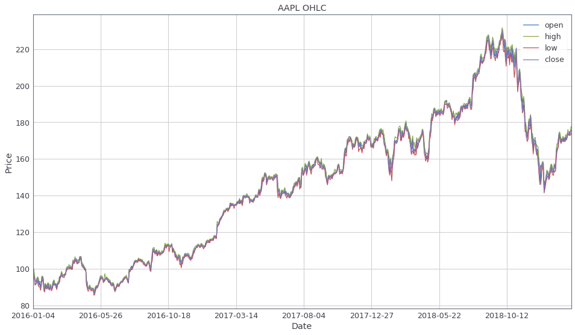

```python
# 캔들차트 그리기는 링크 걸기
ohlc.plot(figsize=(16,9))
plt.title(symbol + ' OHLC')
plt.ylabel('Price')
plt.xlabel('Date');
```

Series에서 사용하였던 기본적인 통계량 계산 함수들도 그래도 사용가능합니다. 여기서 Series와 다른점은 괄호안에 axis라는 파라미터가 들어간다는것 입니다. 이는 해당 함수를 계산하는 방향을 나타내며 행(row)을 따라가며 계산을 할 경우 `axis=0`, 열(column)을 따라가며 계산할 경우 `axis=1`을 입력해 주면 됩니다. 아래 예제를 보면 쉽게 이해가 가능합니다.

```python
prices.mean(axis=0)
```

```
open      1.454032e+02
high      1.466543e+02
low       1.441922e+02
close     1.454709e+02
volume    3.313652e+07
dtype: float64
```

```python
prices.std(axis=0)
```

```
open      3.805207e+01
high      3.843831e+01
low       3.761731e+01
close     3.801495e+01
volume    1.518350e+07
dtype: float64
```

Series와 마찬가지로 describe() 메서드를 활용하여 요약된 통계량 정보를 한눈에 확인 가능합니다.

```python
prices.describe()
```

|  | open | high | low | close | volume |
| --- | --- | --- | --- | --- | --- |
| count | 796.000000 | 796.000000 | 796.000000 | 796.000000 | 7.960000e+02 |
| mean | 145.403219 | 146.654327 | 144.192244 | 145.470924 | 3.313652e+07 |
| std | 38.052073 | 38.438314 | 37.617308 | 38.014947 | 1.518350e+07 |
| min | 85.983000 | 87.578500 | 85.476700 | 86.307900 | 1.147592e+07 |
| 25% | 107.283450 | 108.485500 | 106.716250 | 107.691450 | 2.331280e+07 |
| 50% | 149.929500 | 150.813550 | 148.990900 | 149.914900 | 2.879982e+07 |
| 75% | 171.368400 | 172.467850 | 170.107975 | 171.574550 | 3.836883e+07 |
| max | 228.995300 | 231.664500 | 228.003100 | 230.275400 | 1.333697e+08 |

스칼라 계산도 Series와 마찬가지로 각각 데이터에 적용됩니다.

```python
(100 * prices - 100).head()
```

| date | open | high | low | close | volume |
| --- | --- | --- | --- | --- | --- |
| 2016-01-04 | 9591.11 | 9851.59 | 9533.50 | 9849.89 | 6764938600 |
| 2016-01-05 | 9887.67 | 9897.11 | 9572.22 | 9600.55 | 5579099100 |
| 2016-01-06 | 9397.49 | 9568.44 | 9332.33 | 9410.72 | 6845738700 |
| 2016-01-07 | 9219.93 | 9356.88 | 9007.43 | 9009.32 | 8109442700 |
| 2016-01-08 | 9207.66 | 9260.55 | 9038.60 | 9057.49 | 7079801500 |

게시글의 첨부파일을 보시면 close_data.csv 라는 파일이 있습니다. 해당 엑셀파일은 코스피, 삼성전자 그리고 SK하이닉스의 2018년 동안의 수정종가를 담고있는 파일입니다.

pandas는 엑셀 csv 파일을 DataFrame으로 읽어올 수 있는 기능을 제공합니다. 첨부파일에 있는 csv파일을 현재 실행중인 주피터노트북이 저장된 폴더에 저장해 주시고 다음과 같이 pd.read_csv함수를 활용해 csv파일의 데이터를 읽어 옵니다.

```python
# dt열을 인덱스 열로 지정하여 데이터를 읽어옵니다.
close_prices = pd.read_csv('close_data.csv', index_col='dt')
close_prices.head()
```

| dt | KOSPI_close | SAMSUNG_close | SK_Hynix_Close |
| --- | --- | --- | --- |
| 2018-01-02 | 2479.65 | 51020.0 | 76600.0 |
| 2018-01-03 | 2486.35 | 51620.0 | 77700.0 |
| 2018-01-04 | 2466.46 | 51080.0 | 77100.0 |
| 2018-01-05 | 2497.52 | 52120.0 | 79300.0 |
| 2018-01-08 | 2513.28 | 52020.0 | 78200.0 |

```python
close_prices.tail() # 마지막 5개의 데이터를 확인합니다.
```

| dt | KOSPI_close | SAMSUNG_close | SK_Hynix_Close |
| --- | --- | --- | --- |
| 2018-12-21 | 2061.49 | 38650.0 | 60000.0 |
| 2018-12-24 | 2055.01 | 38800.0 | 60400.0 |
| 2018-12-26 | 2028.01 | 38350.0 | 60100.0 |
| 2018-12-27 | 2028.44 | 38250.0 | 61600.0 |
| 2018-12-28 | 2041.04 | 38700.0 | 60500.0 |

csv 파일을 데이터가 정상적으로 읽어졌음을 확인하였습니다. 인덱스의 데이터 타입을 체크해 보도록 하겠습니다.

```python
type(close_prices.index[0])
```

```
str
```

저번처럼 문자열 타입이기 때문에 파이썬이 날짜로 인식하도록 아래와 같이 인덱스를 datatime형식으로 변경해 줍니다.

```python
close_prices.index = pd.to_datetime(close_prices.index)
```

각 종목별 퍼센트 수익률을 시리즈에서 처럼 pct_change() 메서드를 활용해 손쉽게 계산 가능합니다.

```python
mult_returns = close_prices.pct_change()[1:]
mult_returns.columns = ['KOSPI_return','SAMSUNG_return','SK_Hynix_return']
mult_returns.head()
```

| dt | KOSPI_return | SAMSUNG_return | SK_Hynix_return |
| --- | --- | --- | --- |
| 2018-01-03 | 0.002702 | 0.011760 | 0.014360 |
| 2018-01-04 | -0.008000 | -0.010461 | -0.007722 |
| 2018-01-05 | 0.012593 | 0.020360 | 0.028534 |
| 2018-01-08 | 0.006310 | -0.001919 | -0.013871 |
| 2018-01-09 | -0.001214 | -0.031142 | -0.016624 |

종목간의 직관적 가격 움직임의 비교를 위해 같은 스케일에서 움직이도록 정규화를 진행합니다. norm_returns 라는 새로운 DataFrame에 종목별로 정규화 시킨 값들을 저장하여 그래프를 출력합니다.

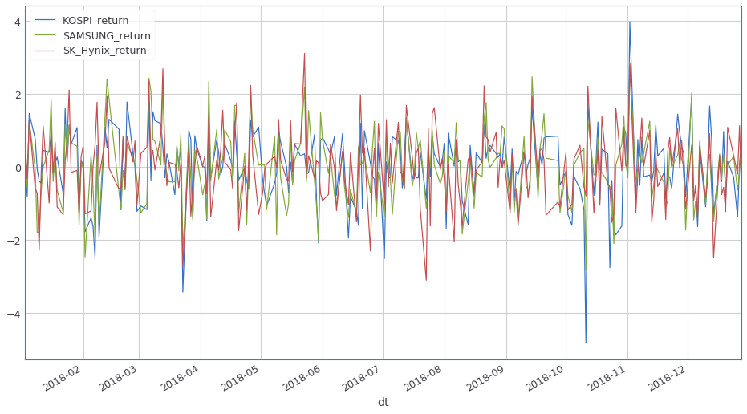

```python
norm_returns = (mult_returns - mult_returns.mean(axis=0))/mult_returns.std(axis=0)
norm_returns.plot(figsize=(16,9));
```

각 종목의 20일 이동평균선을 구해보도록 하겠습니다. 시리즈에서 처럼 rolling(window=20)과 같은 메서드를 활용하여 손쉽게 계산이 가능합니다.

```python
moving_average = close_prices.rolling(window=20).mean()
moving_average.columns = ['KOSPI-MA20','SAMSUNG-MA20','SK_Hynix-MA20']
```

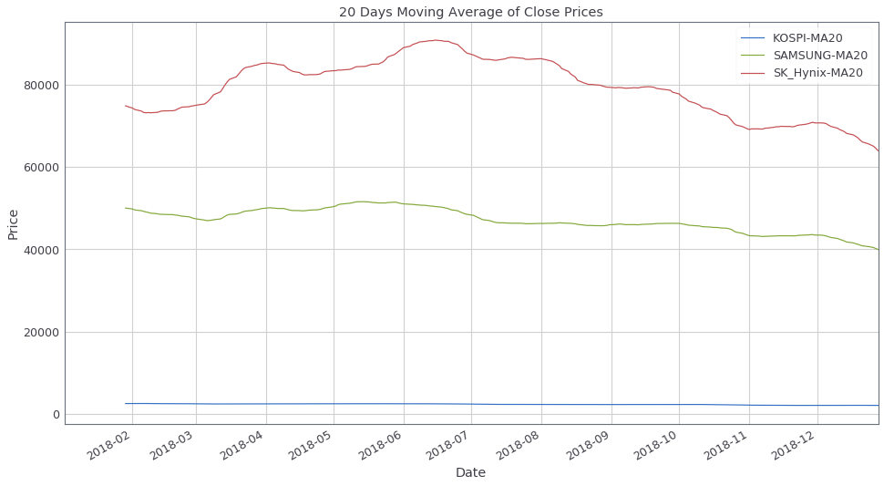

```python
moving_average.plot(figsize=(16,9))
plt.title("20 Days Moving Average of Close Prices")
plt.xlabel("Date")
plt.ylabel("Price")
plt.legend();
```